# MySuperLearner: Comprehensive Example and Evaluation

Author

MySuperLearner Package

Published

November 26, 2025

# Introduction

This document demonstrates the **mysuperlearner** package, a comprehensive Python implementation of the SuperLearner ensemble method with R SuperLearner-like functionality. We’ll walk through:

1. Basic SuperLearner usage with different meta-learners
2. External cross-validation for unbiased performance evaluation
3. Detailed visualizations including forest plots and ROC curves
4. Performance comparison across methods

## Package Overview

The SuperLearner algorithm is an ensemble method that optimally combines multiple machine learning algorithms using cross-validation. Key features of this implementation include:

- **R SuperLearner compatibility**: Methods like `method.NNloglik` and `method.AUC`
- **Robust error handling**: Comprehensive error tracking per learner
- **External CV evaluation**: Similar to R’s `CV.SuperLearner`
- **Multiple meta-learners**: NNLogLik, AUC, NNLS, and Logistic Regression

# Setup and Data Generation

```python
import numpy as np
import pandas as pd
import matplotlib.pyplot as plt
import seaborn as sns
from sklearn.datasets import make_classification
from sklearn.model_selection import train_test_split
from sklearn.metrics import roc_auc_score, accuracy_score, roc_curve, auc
from sklearn.ensemble import RandomForestClassifier
from sklearn.linear_model import LogisticRegression
from sklearn.svm import SVC

from mysuperlearner import ExtendedSuperLearner, visualization
from mysuperlearner.evaluation import evaluate_super_learner_cv

# Set style
sns.set_style("whitegrid")
plt.rcParams['figure.figsize'] = (10, 6)

print("=" * 70)
print("MySuperLearner Comprehensive Analysis")
print("=" * 70)
```

```
======================================================================
MySuperLearner Comprehensive Analysis
======================================================================
```

## Generate Synthetic Dataset

We’ll create a **challenging** binary classification problem with limited signal: only 3 out of 20 features are informative, with 10% label noise added to make prediction difficult.

```python
# Generate challenging synthetic data
np.random.seed(42)
X, y = make_classification(
    n_samples=1000,
    n_features=20,
    n_informative=3,      # Only 3 informative features (challenging!)
    n_redundant=2,        # 2 redundant features
    n_repeated=0,
    n_clusters_per_class=2,
    flip_y=0.1,          # Add 10% label noise
    class_sep=0.5,       # Reduce class separation
    random_state=42
)

X_train, X_test, y_train, y_test = train_test_split(
    X, y, test_size=0.2, random_state=42
)

print(f"\n{'Dataset Summary':^70}")
print("=" * 70)
print(f"Training set: {X_train.shape[0]} samples")
print(f"Test set: {X_test.shape[0]} samples")
print(f"Features: {X_train.shape[1]}")
print(f"Informative features: 3 (15% of total)")
print(f"Label noise: 10%")
print(f"Classes: {np.unique(y)}")
print(f"Class balance: {np.mean(y):.2%} positive")
```

```
                           Dataset Summary
======================================================================
Training set: 800 samples
Test set: 200 samples
Features: 20
Informative features: 3 (15% of total)
Label noise: 10%
Classes: [0 1]
Class balance: 50.50% positive
```

## Define Base Learners

We’ll use diverse base learners including a simple intercept-only baseline (equivalent to R’s `SL.mean`):

```python
from mysuperlearner import InterceptOnlyEstimator

learners = [
    ('Intercept', InterceptOnlyEstimator()),  # Simple baseline (R's SL.mean)
    ('RandomForest', RandomForestClassifier(n_estimators=100, random_state=42)),
    ('LogisticRegression', LogisticRegression(max_iter=1000, random_state=42)),
    ('SVM', SVC(probability=True, random_state=42))
]

print("\nBase Learners:")
print("  - Intercept: Predicts training set mean (baseline)")
print("  - RandomForest: Ensemble of decision trees")
print("  - LogisticRegression: Linear classifier")
print("  - SVM: Support vector machine with RBF kernel")
```

```
Base Learners:
  - Intercept: Predicts training set mean (baseline)
  - RandomForest: Ensemble of decision trees
  - LogisticRegression: Linear classifier
  - SVM: Support vector machine with RBF kernel
```

# Example 1: Basic SuperLearner with NNLogLik

The Non-Negative Log-Likelihood (NNLogLik) meta-learner is the recommended method for binary classification, equivalent to R’s `method.NNloglik`.

```python
print("\n" + "=" * 70)
print("Training SuperLearner with NNLogLik Meta-Learner")
print("=" * 70)

sl = ExtendedSuperLearner(
    method='nnloglik',
    folds=5,
    random_state=42,
    verbose=False
)

sl.fit_explicit(X_train, y_train, learners)

# Make predictions
y_pred_proba = sl.predict_proba(X_test)[:, 1]
y_pred = sl.predict(X_test)

# Evaluate
auc_score = roc_auc_score(y_test, y_pred_proba)
acc_score = accuracy_score(y_test, y_pred)

print(f"\nTest Set Performance:")
print(f"  AUC: {auc_score:.4f}")
print(f"  Accuracy: {acc_score:.4f}")

# Get diagnostics
diagnostics = sl.get_diagnostics()
print(f"\nModel Diagnostics:")
print(f"  Method: {diagnostics['method']}")
print(f"  Inner CV folds: {diagnostics['n_folds']}")
print(f"  Meta-learner type: {diagnostics['meta_learner_type']}")
if 'cv_scores' in diagnostics and diagnostics['cv_scores']:
    print("  CV AUC scores:")
    for name, score in diagnostics['cv_scores'].items():
        print(f"    {name}: {score:.4f}")
```

```
======================================================================
Training SuperLearner with NNLogLik Meta-Learner
======================================================================

Test Set Performance:
  AUC: 0.8847
  Accuracy: 0.8350

Model Diagnostics:
  Method: nnloglik
  Inner CV folds: 5
  Meta-learner type: NNLogLikEstimator
  CV AUC scores:
    Intercept: 0.4980
    RandomForest: 0.8795
    LogisticRegression: 0.7766
    SVM: 0.8091
```

## Meta-Learner Weights

The meta-learner assigns weights to each base learner, indicating their relative importance in the ensemble.

```
Meta-Learner Weights:
           Learner  Weight
      RandomForest     1.0
         Intercept     0.0
LogisticRegression     0.0
               SVM     0.0
```

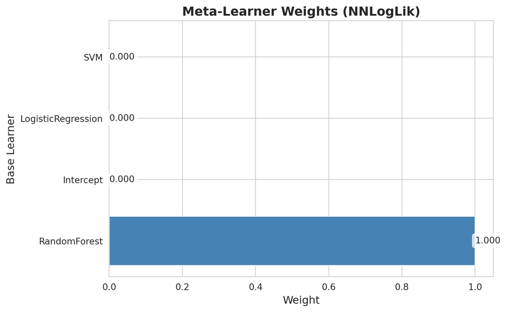

```python
if sl.meta_weights_ is not None:
    weights_df = pd.DataFrame({
        'Learner': [name for name, _ in learners],
        'Weight': sl.meta_weights_
    })
    weights_df = weights_df.sort_values('Weight', ascending=False)
    print("\nMeta-Learner Weights:")
    print(weights_df.to_string(index=False))

    # Visualize weights
    fig, ax = plt.subplots(figsize=(8, 5))
    bars = ax.barh(weights_df['Learner'], weights_df['Weight'], color='steelblue')
    ax.set_xlabel('Weight', fontsize=12)
    ax.set_ylabel('Base Learner', fontsize=12)
    ax.set_title('Meta-Learner Weights (NNLogLik)', fontsize=14, fontweight='bold')

    # Add value labels
    for i, bar in enumerate(bars):
        width = bar.get_width()
        ax.text(width, bar.get_y() + bar.get_height()/2,
                f'{width:.3f}', ha='left', va='center', fontsize=10,
                bbox=dict(boxstyle='round,pad=0.3', facecolor='white', alpha=0.7))

    plt.tight_layout()
    plt.show()
```

# Example 2: Comparing Meta-Learning Methods

Different meta-learning methods may perform differently depending on the dataset. Let’s compare all available methods.

```python
print("\n" + "=" * 70)
print("Comparing Meta-Learning Methods")
print("=" * 70)

methods = ['nnloglik', 'auc', 'nnls', 'logistic']
results = []

for method in methods:
    sl_method = ExtendedSuperLearner(
        method=method,
        folds=5,
        random_state=42,
        verbose=False
    )
    sl_method.fit_explicit(X_train, y_train, learners)

    y_pred_proba = sl_method.predict_proba(X_test)[:, 1]
    auc_score = roc_auc_score(y_test, y_pred_proba)
    acc_score = accuracy_score(y_test, (y_pred_proba >= 0.5).astype(int))

    results.append({
        'Method': method,
        'AUC': auc_score,
        'Accuracy': acc_score
    })

    print(f"  {method:12s}: AUC = {auc_score:.4f}, Accuracy = {acc_score:.4f}")

results_df = pd.DataFrame(results)
```

```
======================================================================
Comparing Meta-Learning Methods
======================================================================
  nnloglik    : AUC = 0.8847, Accuracy = 0.8350
  auc         : AUC = 0.8848, Accuracy = 0.8300
  nnls        : AUC = 0.8847, Accuracy = 0.8350
  logistic    : AUC = 0.8854, Accuracy = 0.8350
```

## Visualization: Method Comparison

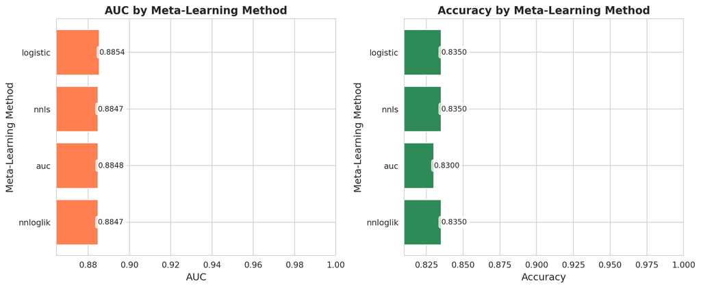

Figure 1: Performance comparison across different meta-learning methods

```python
fig, axes = plt.subplots(1, 2, figsize=(12, 5))

# AUC comparison
axes[0].barh(results_df['Method'], results_df['AUC'], color='coral')
axes[0].set_xlabel('AUC', fontsize=12)
axes[0].set_ylabel('Meta-Learning Method', fontsize=12)
axes[0].set_title('AUC by Meta-Learning Method', fontsize=13, fontweight='bold')
axes[0].set_xlim([results_df['AUC'].min() - 0.02, 1.0])

# Add value labels
for i, (method, auc_val) in enumerate(zip(results_df['Method'], results_df['AUC'])):
    axes[0].text(auc_val, i, f'{auc_val:.4f}',
                ha='left', va='center', fontsize=9,
                bbox=dict(boxstyle='round,pad=0.3', facecolor='white', alpha=0.7))

# Accuracy comparison
axes[1].barh(results_df['Method'], results_df['Accuracy'], color='seagreen')
axes[1].set_xlabel('Accuracy', fontsize=12)
axes[1].set_ylabel('Meta-Learning Method', fontsize=12)
axes[1].set_title('Accuracy by Meta-Learning Method', fontsize=13, fontweight='bold')
axes[1].set_xlim([results_df['Accuracy'].min() - 0.02, 1.0])

# Add value labels
for i, (method, acc_val) in enumerate(zip(results_df['Method'], results_df['Accuracy'])):
    axes[1].text(acc_val, i, f'{acc_val:.4f}',
                ha='left', va='center', fontsize=9,
                bbox=dict(boxstyle='round,pad=0.3', facecolor='white', alpha=0.7))

plt.tight_layout()
plt.show()
```

# Example 3: External Cross-Validation

External cross-validation provides an unbiased estimate of the SuperLearner’s performance, similar to R’s `CV.SuperLearner` function.

```python
print("\n" + "=" * 70)
print("External Cross-Validation (like R's CV.SuperLearner)")
print("=" * 70)

sl_cv = ExtendedSuperLearner(
    method='nnloglik',
    folds=5,
    random_state=42,
    verbose=False
)

# Use return_object=True and return_predictions=True for full functionality
cv_results = evaluate_super_learner_cv(
    X=X,
    y=y,
    base_learners=learners,
    super_learner=sl_cv,
    outer_folds=5,
    random_state=42,
    n_jobs=1,
    return_predictions=True,
    return_object=True
)

print(f"\nExternal CV completed: {cv_results}")
print(f"  - {cv_results.metrics.shape[0]} total evaluations")
print(f"  - Predictions stored: {cv_results.predictions is not None}")
```

```
======================================================================
External Cross-Validation (like R's CV.SuperLearner)
======================================================================

External CV completed: SuperLearnerCVResults(n_folds=5, n_learners=5, has_predictions=True)

Summary Statistics:
                         auc                   logloss                  \
                        mean       std count      mean       std count
learner
Intercept           0.500000  0.000000     5  0.693097  0.000000     5
LogisticRegression  0.780758  0.019614     5  0.564578  0.024231     5
RandomForest        0.887239  0.018958     5  0.444155  0.019457     5
SVM                 0.811001  0.027959     5  0.525156  0.030633     5
SuperLearner        0.887239  0.018958     5  0.444379  0.019537     5

                   accuracy                       auc             logloss  \
                       mean       std count  ci_lower  ci_upper  ci_lower
learner
Intercept             0.505  0.000000     5  0.500000  0.500000  0.693097
LogisticRegression    0.702  0.018235     5  0.763565  0.797951  0.543339
RandomForest          0.812  0.027065     5  0.870621  0.903856  0.427100
SVM                   0.742  0.027065     5  0.786494  0.835508  0.498305
SuperLearner          0.812  0.027065     5  0.870621  0.903856  0.427254

                              accuracy
                    ci_upper  ci_lower  ci_upper
learner
Intercept           0.693097  0.505000  0.505000
LogisticRegression  0.585817  0.686017  0.717983
RandomForest        0.461209  0.788277  0.835723
SVM                 0.552006  0.718277  0.765723
SuperLearner        0.461503  0.788277  0.835723
  - 25 total evaluations
  - Predictions stored: True
```

## Summary Statistics

Table 1: Cross-validation performance summary (mean ± std with 95% CI)

```python
# Use the built-in summary method
summary = cv_results.summary()
print("\nCross-Validation Results:")
print(summary.round(4))

# Create a formatted display table for key metrics
display_data = []
learner_order = ['SuperLearner'] + [name for name, _ in learners]
for learner in learner_order:
    if learner in summary.index:
        display_data.append({
            'Learner': learner,
            'Learner Type': 'Ensemble' if learner == 'SuperLearner' else 'Base',
            'AUC (mean ± std)': f"{summary.loc[learner, ('auc', 'mean')]:.4f} ± {summary.loc[learner, ('auc', 'std')]:.4f}",
            'AUC 95% CI': f"[{summary.loc[learner, ('auc', 'ci_lower')]:.4f}, {summary.loc[learner, ('auc', 'ci_upper')]:.4f}]",
            'Accuracy': f"{summary.loc[learner, ('accuracy', 'mean')]:.4f} ± {summary.loc[learner, ('accuracy', 'std')]:.4f}"
        })

display_df = pd.DataFrame(display_data)
print("\n" + display_df.to_string(index=False))
```

```
Cross-Validation Results:
                       auc               logloss               accuracy  \
                      mean     std count    mean     std count     mean
learner
Intercept           0.5000  0.0000     5  0.6931  0.0000     5    0.505
LogisticRegression  0.7808  0.0196     5  0.5646  0.0242     5    0.702
RandomForest        0.8872  0.0190     5  0.4442  0.0195     5    0.812
SVM                 0.8110  0.0280     5  0.5252  0.0306     5    0.742
SuperLearner        0.8872  0.0190     5  0.4444  0.0195     5    0.812

                                      auc           logloss          accuracy  \
                       std count ci_lower ci_upper ci_lower ci_upper ci_lower
learner
Intercept           0.0000     5   0.5000   0.5000   0.6931   0.6931   0.5050
LogisticRegression  0.0182     5   0.7636   0.7980   0.5433   0.5858   0.6860
RandomForest        0.0271     5   0.8706   0.9039   0.4271   0.4612   0.7883
SVM                 0.0271     5   0.7865   0.8355   0.4983   0.5520   0.7183
SuperLearner        0.0271     5   0.8706   0.9039   0.4273   0.4615   0.7883


                   ci_upper
learner
Intercept            0.5050
LogisticRegression   0.7180
RandomForest         0.8357
SVM                  0.7657
SuperLearner         0.8357

           Learner Learner Type AUC (mean ± std)       AUC 95% CI        Accuracy
      SuperLearner     Ensemble  0.8872 ± 0.0190 [0.8706, 0.9039] 0.8120 ± 0.0271
         Intercept         Base  0.5000 ± 0.0000 [0.5000, 0.5000] 0.5050 ± 0.0000
      RandomForest         Base  0.8872 ± 0.0190 [0.8706, 0.9039] 0.8120 ± 0.0271
LogisticRegression         Base  0.7808 ± 0.0196 [0.7636, 0.7980] 0.7020 ± 0.0182
               SVM         Base  0.8110 ± 0.0280 [0.7865, 0.8355] 0.7420 ± 0.0271
```

## Performance Comparison

```python
# Use the built-in comparison method
comparison = cv_results.compare_to_best()
print("\nSuperLearner vs. Best Base Learner:")
print(comparison.round(4))
```

```
SuperLearner vs. Best Base Learner:
     metric  SuperLearner  Best_Base Best_Base_Name  Improvement  \
0       auc        0.8872     0.8872   RandomForest       0.0000
1   logloss        0.4444     0.6931      Intercept      -0.2487
2  accuracy        0.8120     0.8120   RandomForest      -0.0000

   Improvement_Pct
0           0.0000
1         -35.8851
2          -0.0000
```

## Forest Plot: Cross-Validated AUC

A forest plot shows the distribution of AUC scores across folds for each learner, with confidence intervals.

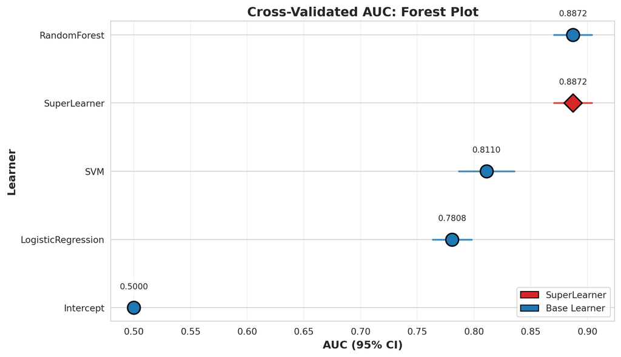

Figure 2: Forest plot showing cross-validated AUC scores with 95% confidence intervals

```python
# Use the built-in plotting method (or standalone function)
# Option 1: Using method
fig, ax = cv_results.plot_forest(metric='auc')

# Option 2: Using standalone function (commented out)
# fig, ax = visualization.plot_cv_forest(cv_results.metrics, metric='auc')

plt.show()
```

## Box Plot: AUC Distribution Across Folds

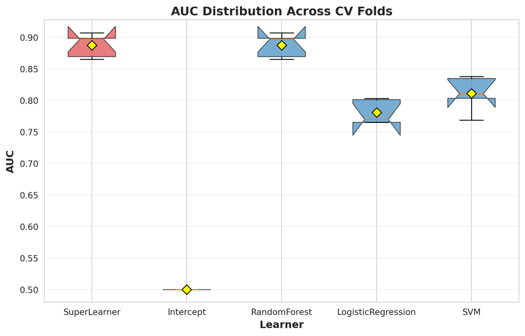

Figure 3: Distribution of AUC scores across cross-validation folds

```python
# Use the built-in plotting method
fig, ax = cv_results.plot_boxplot(metric='auc')
plt.show()
```

# ROC Curve Analysis

With fold-level predictions stored, we can now generate cross-validated ROC curves that provide a more robust assessment of model performance.

## Cross-Validated ROC Curves

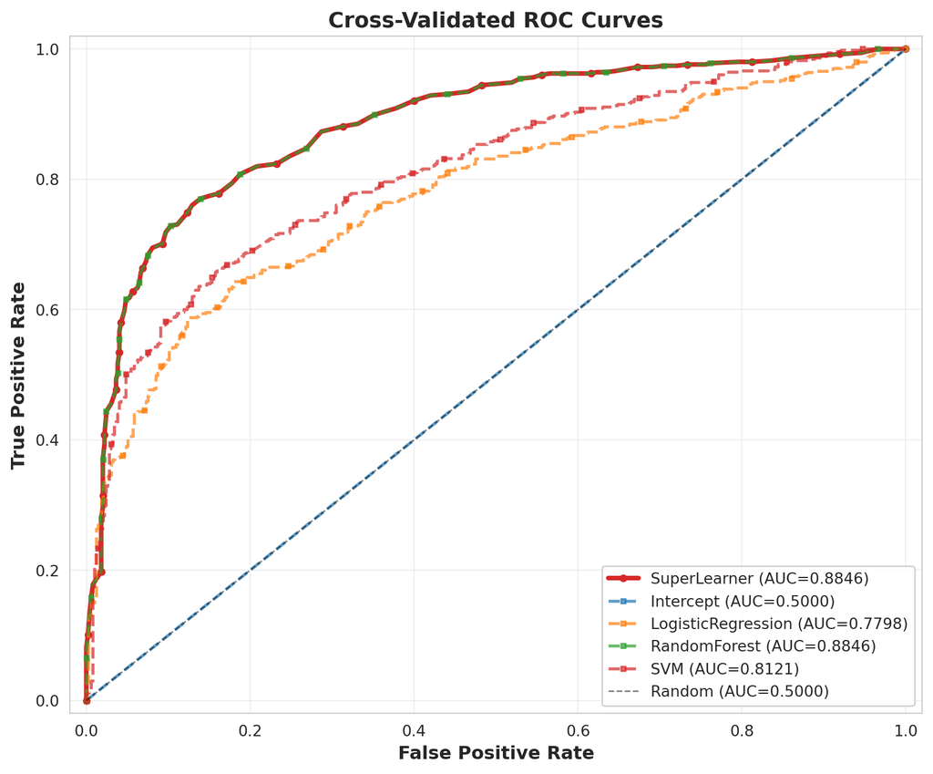

Figure 4: Cross-validated ROC curves for SuperLearner and individual base learners

```python
# Use the built-in plotting method with CV predictions
fig, ax = cv_results.plot_roc_curves()
plt.show()
```

## Calibration Curves

Calibration curves show how well the predicted probabilities match the actual frequencies of positive outcomes.

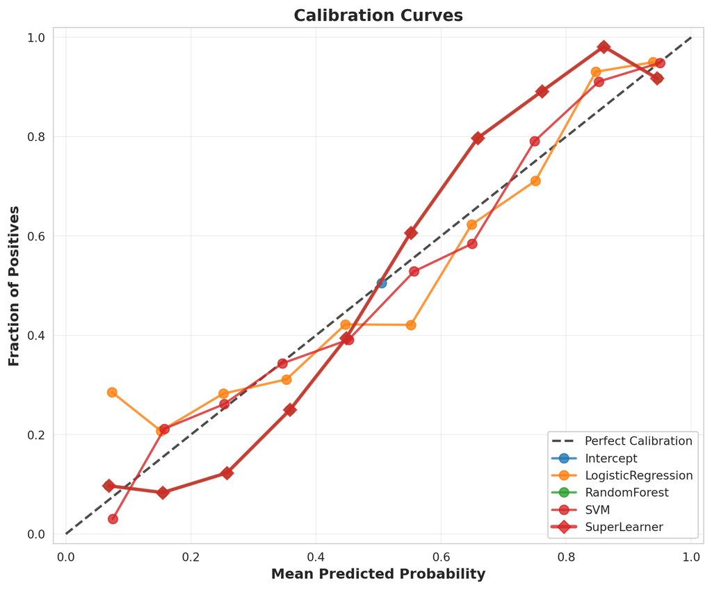

Figure 5: Calibration curves showing predicted vs. observed probabilities

```python
# Use the built-in plotting method
fig, ax = cv_results.plot_calibration(n_bins=10)
plt.show()
```

# Summary and Conclusions

## Key Findings

```python
# Use the summary method from the result object
summary = cv_results.summary(metrics=['auc', 'accuracy'])

# Create a simplified summary table
summary_stats = {
    'Metric': ['Mean AUC', 'Std AUC', 'Mean Accuracy', 'Std Accuracy']
}

for learner in ['SuperLearner'] + [name for name, _ in learners]:
    if learner in summary.index:
        summary_stats[learner] = [
            summary.loc[learner, ('auc', 'mean')],
            summary.loc[learner, ('auc', 'std')],
            summary.loc[learner, ('accuracy', 'mean')],
            summary.loc[learner, ('accuracy', 'std')]
        ]

summary_table = pd.DataFrame(summary_stats)
print("\nFinal Summary:")
print(summary_table.to_string(index=False))
```

```
Final Summary:
       Metric  SuperLearner  Intercept  RandomForest  LogisticRegression      SVM
     Mean AUC      0.887239      0.500      0.887239            0.780758 0.811001
      Std AUC      0.018958      0.000      0.018958            0.019614 0.027959
Mean Accuracy      0.812000      0.505      0.812000            0.702000 0.742000
 Std Accuracy      0.027065      0.000      0.027065            0.018235 0.027065
```

## Session Information

```python
import sys
import sklearn

print(f"Python version: {sys.version}")
print(f"NumPy version: {np.__version__}")
print(f"Pandas version: {pd.__version__}")
print(f"Scikit-learn version: {sklearn.__version__}")
print(f"Matplotlib version: {plt.matplotlib.__version__}")
print(f"Seaborn version: {sns.__version__}")
```

```
Python version: 3.11.12 | packaged by conda-forge | (main, Apr 10 2025, 22:23:25) [GCC 13.3.0]
NumPy version: 2.2.5
Pandas version: 2.2.3
Scikit-learn version: 1.5.2
Matplotlib version: 3.10.1
Seaborn version: 0.13.2
```